# Sesión 05 · Guía de argumentos de ggplot2

Material de consulta — Introducción a R, semestre 2027-1

Autor/a

Dra. Yalbi Itzel Balderas-Martínez

## Cómo usar esta guía

Esta guía acompaña al notebook de estadística descriptiva. No hay que leerla de corrido: cuando un argumento del notebook no quede claro, búscalo aquí en el índice.

Cada argumento trae:

- **qué hace**, en palabras sencillas;
- **con qué tipo de variable** se usa (categórica o numérica);
- **en qué se diferencia** de otros que se parecen;
- una **gráfica** que lo muestra, con su código.

Todos los ejemplos usan datos del notebook. Corre primero este bloque:

```r
library(ggplot2)
library(MASS) # trae birthwt

# Centrales nucleares por país (OpenLearn, sección 2.1)
nucleares <- data.frame(
  pais = c("Canadá", "Checoslovaquia", "Alemania Oriental", "Francia",
           "Japón", "Corea del Sur", "Unión Soviética", "España", "Suecia",
           "Reino Unido", "Estados Unidos", "Alemania Occidental"),
  n = c(22, 13, 10, 52, 43, 9, 73, 10, 12, 41, 119, 23)
)

# Fuerza laboral de Estados Unidos en 1986, en millones (OpenLearn, sección 2.2)
empleo <- data.frame(
  tipo = rep(c("Profesional", "Industrial", "Oficios", "Ventas", "Servicios",
               "Oficina", "Agrícola"), 2),
  sexo = rep(c("Hombres", "Mujeres"), each = 7),
  millones = c(15.00, 12.90, 12.30, 6.90, 5.80, 3.50, 2.90,
               11.60, 4.45, 1.25, 6.45, 9.60, 14.30, 0.65)
)

# smoke viene como 0 y 1: se convierte en dos grupos con nombre
birthwt$fuma <- factor(birthwt$smoke, levels = c(0, 1),
                       labels = c("No fumó", "Fumó"))
```

## 1. Antes de los argumentos: mapear o fijar

Casi toda la personalización de una gráfica se decide con una sola pregunta: **¿el aspecto depende de los datos, o es igual para todos?**

|  | Dónde se escribe | Qué recibe | Ejemplo | ¿Crea leyenda? |
| --- | --- | --- | --- | --- |
| **Mapear** | dentro de `aes()` | el **nombre de una columna** | `aes(fill = sexo)` | sí |
| **Fijar** | fuera de `aes()`, en la capa | un **valor** | `fill = "steelblue"` | no |

Sentido común: en una lista de asistencia, *mapear* es pintar a cada alumna del color de su grupo; *fijar* es usar la misma pluma para todas.

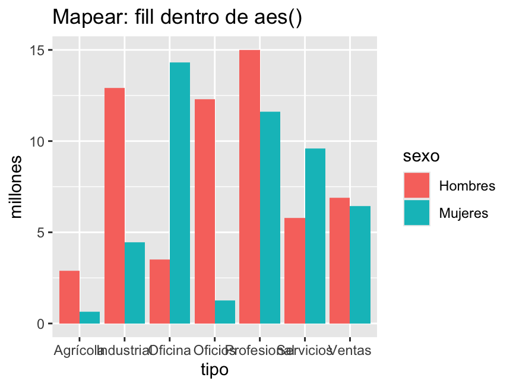

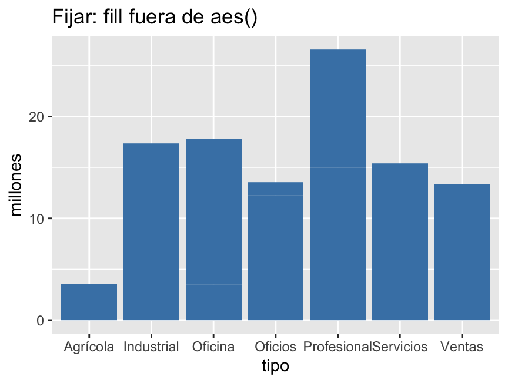

```r
# MAPEAR: el color de relleno depende de la columna sexo
ggplot(empleo, aes(x = tipo, y = millones, fill = sexo)) +
  geom_col(position = "dodge") +
  labs(title = "Mapear: fill dentro de aes()")
# FIJAR: todas las barras del mismo azul
ggplot(empleo, aes(x = tipo, y = millones)) +
  geom_col(fill = "steelblue") +
  labs(title = "Fijar: fill fuera de aes()")
```

**Advertencia**

**El error más común.** Escribir un valor **dentro** de `aes()`: `aes(fill = "steelblue")`. R no pinta de azul: crea una categoría llamada `"steelblue"`, la pinta con el primer color de su paleta (un rojo salmón) y le pone leyenda.

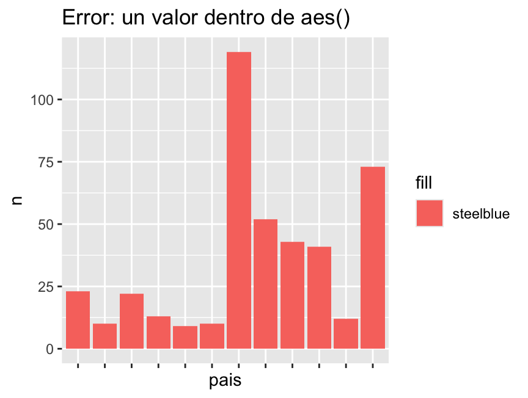

```r
ggplot(nucleares, aes(x = pais, y = n)) +
  geom_col(aes(fill = "steelblue")) + # MAL: el valor va dentro de aes()
  labs(title = "Error: un valor dentro de aes()") +
  theme(axis.text.x = element_blank()) # se ocultan los nombres para ahorrar espacio
```

## 2. Las estéticas: `x`, `y`, `fill`, `color`, `label`

Una **estética** es una propiedad visual que puede depender de los datos: la posición, el color, el tamaño, el texto. Se mapean dentro de `aes()`.

| Estética | Qué controla | Variable categórica | Variable numérica |
| --- | --- | --- | --- |
| `x`, `y` | la posición | una posición por categoría (barras, cajas) | un eje continuo (dispersión, histograma) |
| `fill` | el **relleno** de una figura con área (barra, caja, rebanada) | un color por categoría | un degradado |
| `color` | el **borde** de una figura con área, o el color de puntos, líneas y texto | un color por categoría | un degradado |
| `label` | el texto que escribe `geom_text()` | escribe la categoría | escribe el número |
| `size` | el tamaño de puntos o texto | posible, pero se lee mal | lo natural |
| `alpha` | la transparencia | posible, pero se lee mal | lo natural |

`color` y `colour` son lo mismo: ggplot2 acepta las dos formas.

### `fill` contra `color`

Es la diferencia que más confunde. En una **barra** (o una caja, o una rebanada), `fill` es el relleno y `color` es el **borde**. En un **punto** o una **línea**, el color es `color`: no tienen relleno.

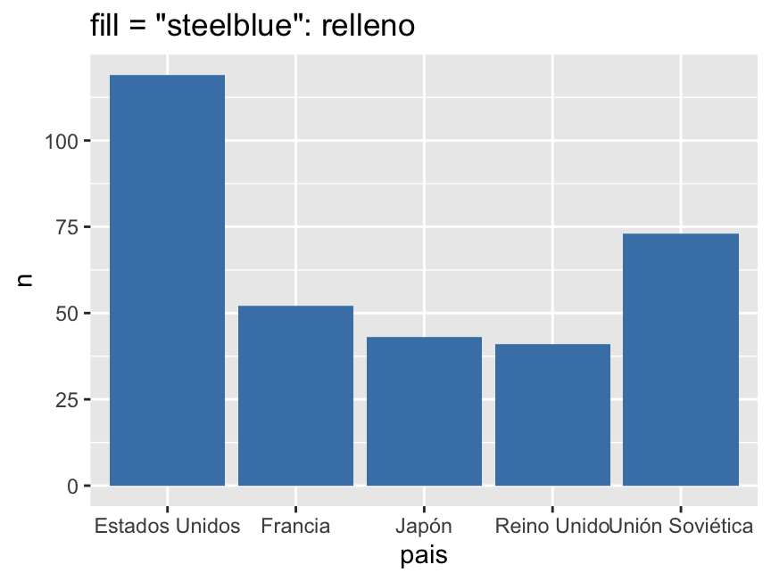

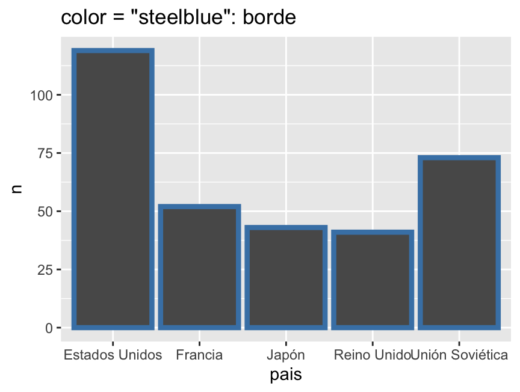

```r
cinco <- nucleares[nucleares$n > 40, ] # solo los países con más de 40

ggplot(cinco, aes(x = pais, y = n)) +
  geom_col(fill = "steelblue") +
  labs(title = 'fill = "steelblue": relleno')
ggplot(cinco, aes(x = pais, y = n)) +
  geom_col(color = "steelblue", linewidth = 1.5) + # linewidth: grosor del borde
  labs(title = 'color = "steelblue": borde')
```

En el notebook, `geom_col(color = "white")` en los pasteles dibuja una **línea blanca** entre rebanadas: es el borde, no el relleno.

### Color con variable categórica o numérica

`fill` y `color` aceptan los dos tipos de variable, pero el resultado cambia:

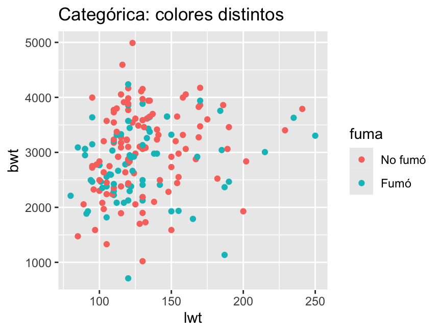

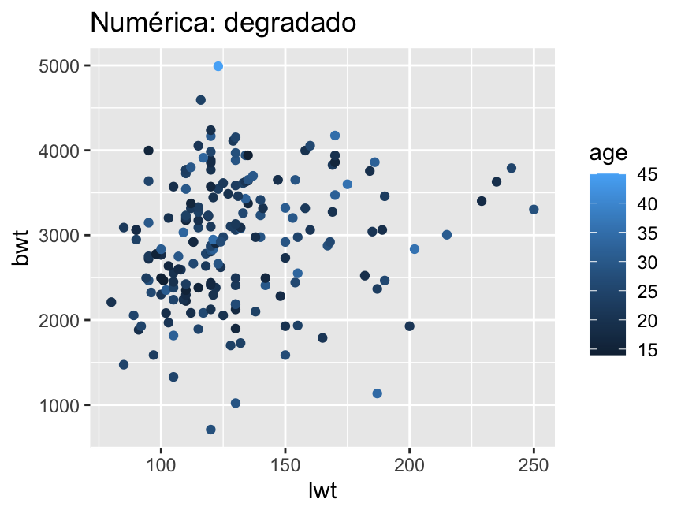

```r
# Categórica (factor): un color distinto por grupo
ggplot(birthwt, aes(x = lwt, y = bwt, color = fuma)) +
  geom_point() +
  labs(title = "Categórica: colores distintos")
# Numérica: un degradado de oscuro a claro
ggplot(birthwt, aes(x = lwt, y = bwt, color = age)) +
  geom_point() +
  labs(title = "Numérica: degradado")
```

**Importante**

Una columna guardada como **número** pero que en realidad es **categoría** (como `smoke`, con 0 y 1) sale como degradado, con valores intermedios como 0.5 que no existen. Por eso se convierte en factor antes de mapearla.

### `label`: el texto de `geom_text()`

`label` solo lo usan las capas que escriben texto. Se mapea a la columna cuyo valor se quiere escribir.

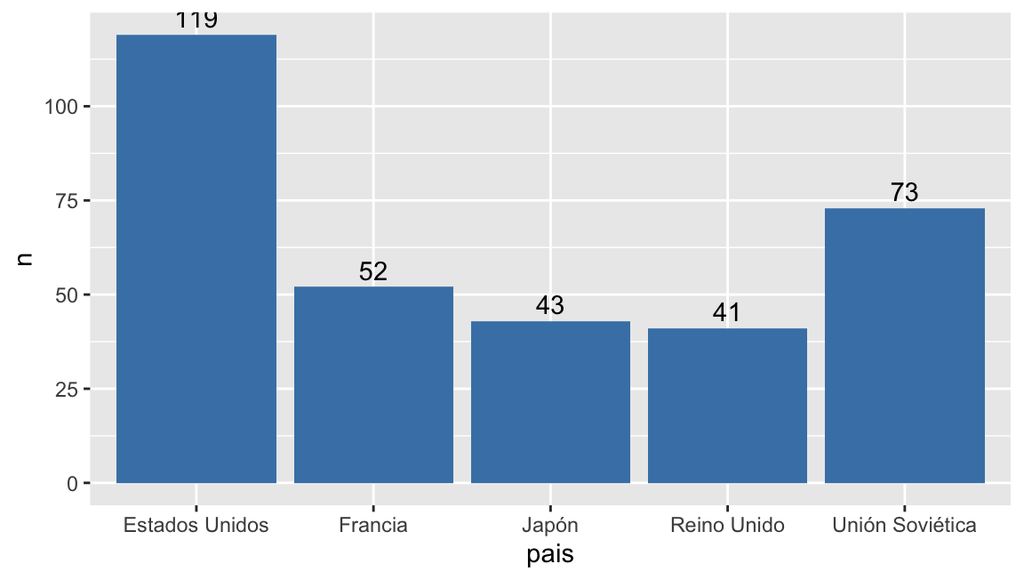

```r
ggplot(cinco, aes(x = pais, y = n)) +
  geom_col(fill = "steelblue") +
  geom_text(aes(label = n), vjust = -0.4) # el número, un poco arriba de la barra
```

## 3. Las capas (geometrías) y sus argumentos

### `geom_col()`, `geom_bar()` y `geom_histogram()`: tres barras distintas

Las tres dibujan barras, pero no reciben lo mismo:

| Capa | Qué necesita | Qué calcula | Tipo de variable en `x` | Ejemplo del notebook |
| --- | --- | --- | --- | --- |
| `geom_col()` | `x` **y** `y` | nada: la altura ya viene en la tabla | categórica | centrales por país |
| `geom_bar()` | **solo** `x` | **cuenta** cuántas filas hay de cada valor | categórica o discreta | consultas (`ftv`) |
| `geom_histogram()` | **solo** `x` | parte el eje en intervalos y **cuenta** cuántos datos caen en cada uno | numérica continua | peso al nacer |

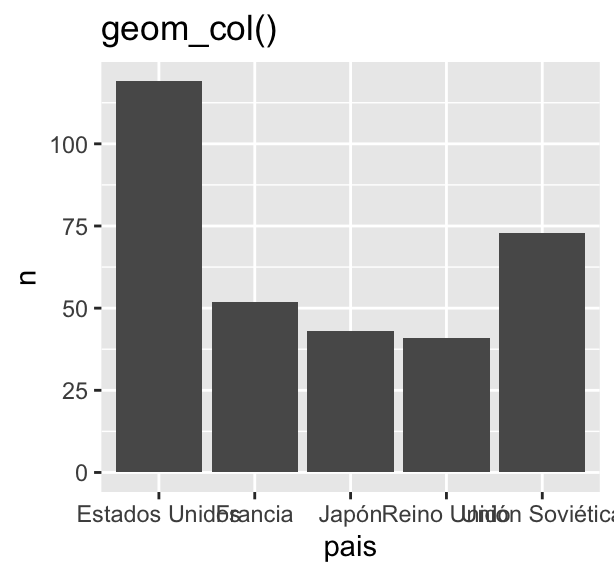

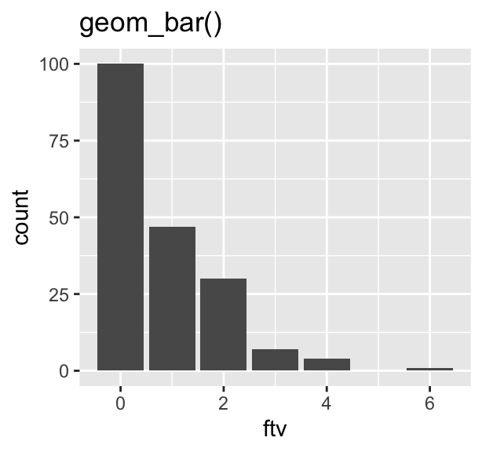

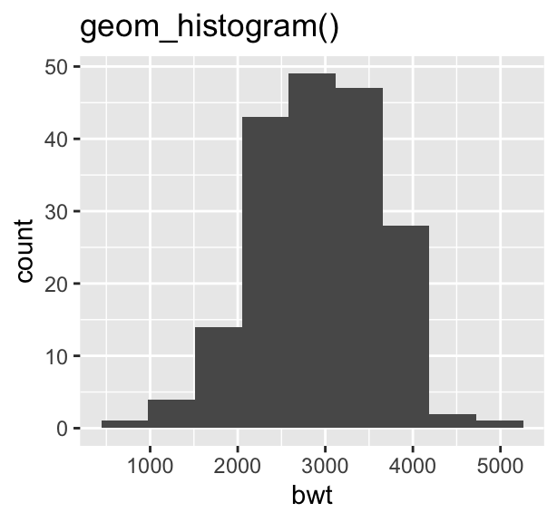

```r
ggplot(cinco, aes(x = pais, y = n)) + # la tabla ya trae n
  geom_col() +
  labs(title = "geom_col()")
ggplot(birthwt, aes(x = ftv)) + # geom_bar cuenta las filas
  geom_bar() +
  labs(title = "geom_bar()")
ggplot(birthwt, aes(x = bwt)) + # geom_histogram agrupa en intervalos
  geom_histogram(bins = 9) +
  labs(title = "geom_histogram()")
```

Una diferencia que se ve: en un **histograma** las barras van **pegadas**, porque el eje es continuo y un intervalo empieza donde acaba el anterior. En las **barras** hay espacio entre ellas, porque las categorías son separadas.

### `width`: el ancho de la barra o la caja

Va de 0 a 1: es la fracción del espacio de cada categoría que ocupa la barra. Por omisión, 0.9.

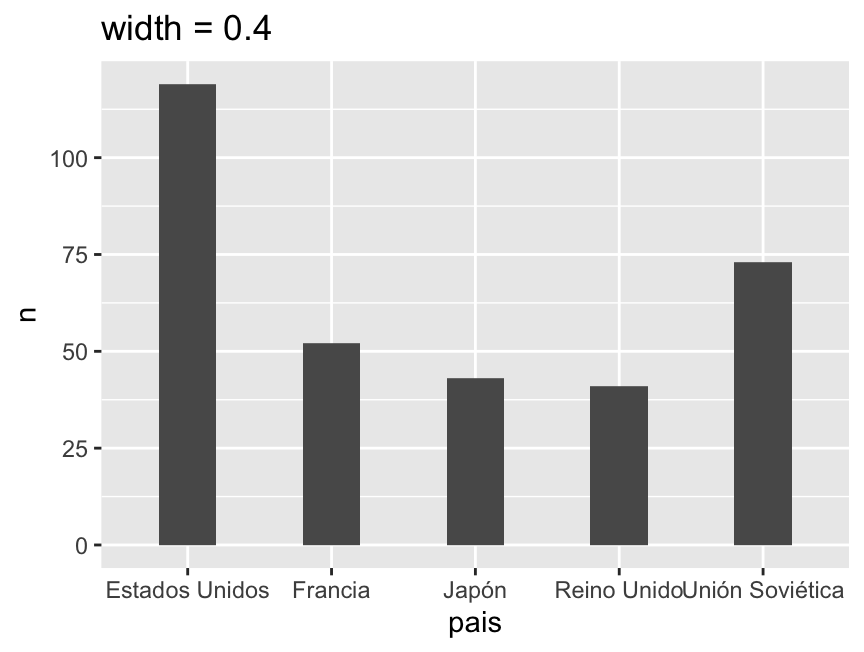

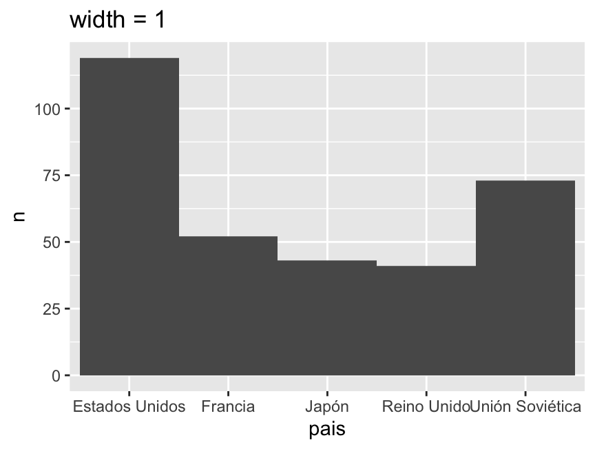

```r
ggplot(cinco, aes(x = pais, y = n)) +
  geom_col(width = 0.4) +
  labs(title = "width = 0.4")
ggplot(cinco, aes(x = pais, y = n)) +
  geom_col(width = 1) +
  labs(title = "width = 1")
```

En el pastel del notebook se usa `width = 1` para que no quede un **agujero en el centro**: con el ancho por omisión, la barra no llena el círculo.

### `position`: qué hacer cuando dos barras caen en el mismo lugar

Cuando hay un `fill` mapeado, cada categoría de `x` tiene **varias** barras. `position` decide cómo acomodarlas:

| Valor | Qué hace | Qué pregunta contesta |
| --- | --- | --- |
| `"stack"` (por omisión) | las **apila** una sobre otra | ¿cuánto hay **en total** en cada categoría? |
| `"dodge"` | las pone **lado a lado** | ¿qué grupo tiene **más** en cada categoría? |
| `"fill"` | las apila y estira cada columna a 100 % | ¿qué **proporción** es de cada grupo? |

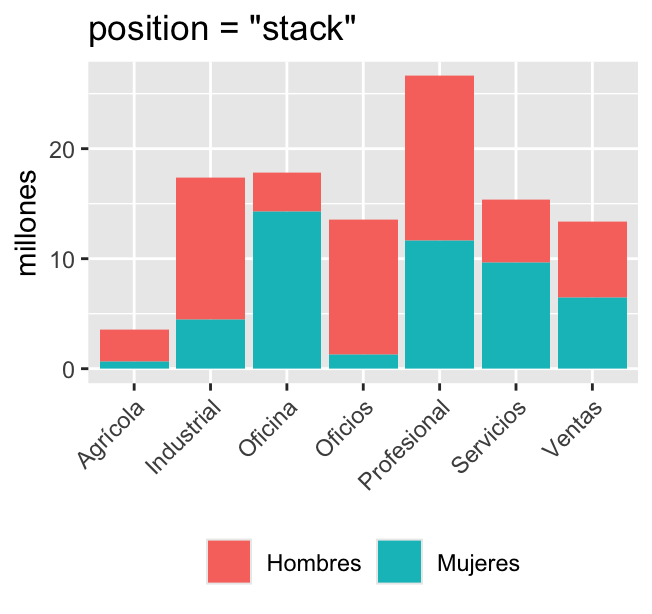

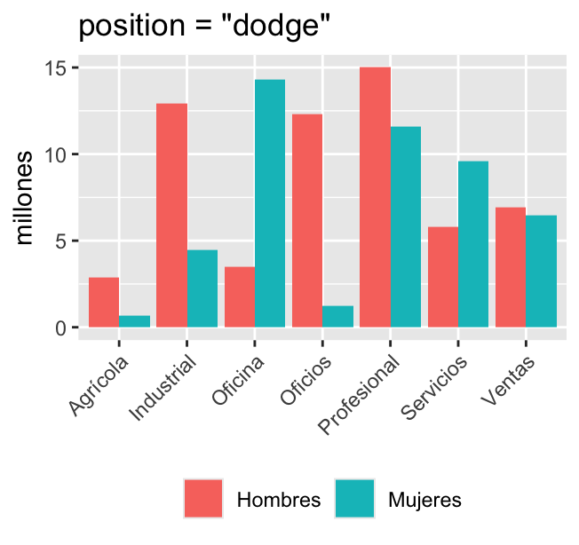

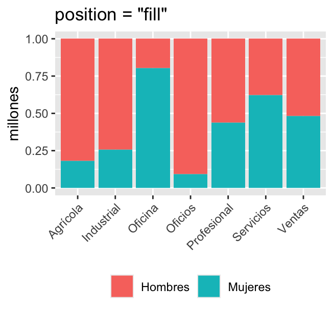

```r
for (p in c("stack", "dodge", "fill")) {
  print(
    ggplot(empleo, aes(x = tipo, y = millones, fill = sexo)) +
      geom_col(position = p) +
      labs(title = paste0('position = "', p, '"'), x = NULL, fill = NULL) +
      theme(axis.text.x = element_text(angle = 45, hjust = 1),
            legend.position = "bottom")
  )
}
```

En el bloque de arriba se usa `for` solo para no repetir el mismo código tres veces; en el notebook cada gráfica va por separado.

### `bins`: cuántos intervalos tiene un histograma

Solo lo usa `geom_histogram()`. Su pariente es `binwidth`, que en lugar de **cuántos** intervalos dice **qué tan anchos** son, en las unidades de la variable. Se usa uno o el otro, no los dos.

| Argumento | Qué dice | Ejemplo con el peso al nacer |
| --- | --- | --- |
| `bins = 9` | quiero 9 intervalos | R calcula el ancho |
| `binwidth = 250` | quiero intervalos de 250 g | R calcula cuántos salen |

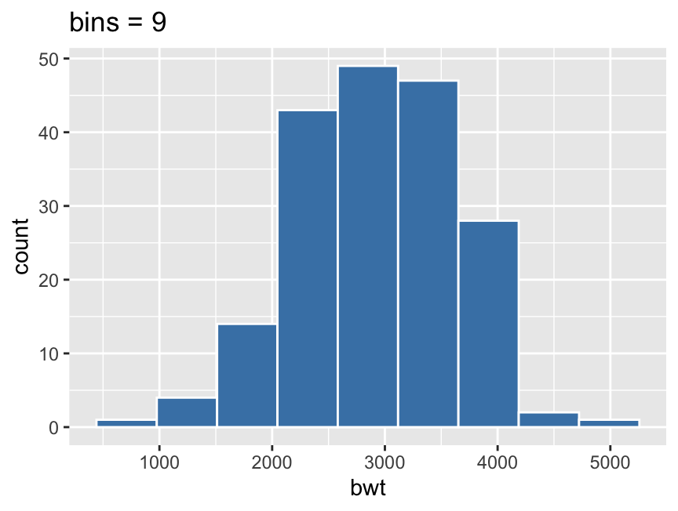

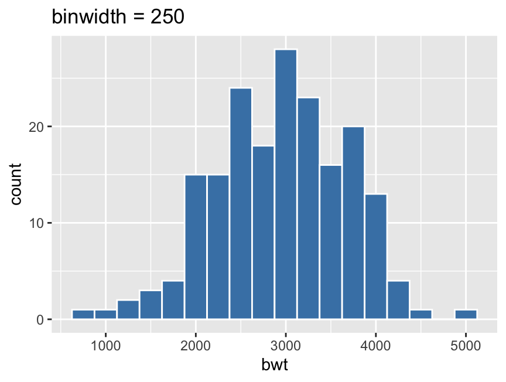

```r
ggplot(birthwt, aes(x = bwt)) +
  geom_histogram(bins = 9, fill = "steelblue", color = "white") +
  labs(title = "bins = 9")
ggplot(birthwt, aes(x = bwt)) +
  geom_histogram(binwidth = 250, fill = "steelblue", color = "white") +
  labs(title = "binwidth = 250")
```

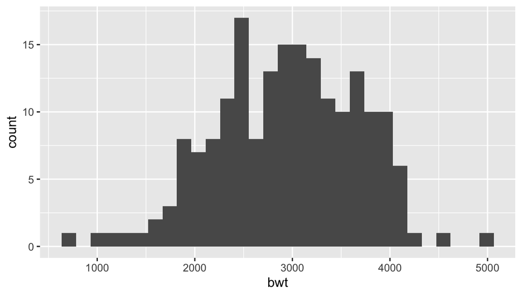

```r
ggplot(birthwt, aes(x = bwt)) +
  geom_histogram()
```

En el histograma, `color = "white"` dibuja el borde blanco que separa las barras; sin él, las barras pegadas se funden en un bloque.

### `geom_point()`: `size` y `alpha`

- `size`: el tamaño del punto. El valor por omisión es 1.5. Fijado (fuera de `aes()`) agranda todos; mapeado a una columna **numérica**, cada punto mide según su valor.
- `alpha`: la transparencia, de **0** (invisible) a **1** (opaco). Sirve cuando los puntos se enciman: donde hay muchos, el color se ve más oscuro.

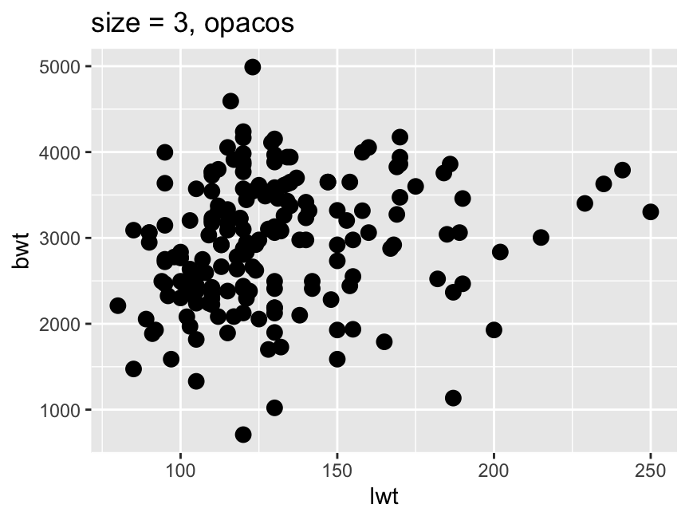

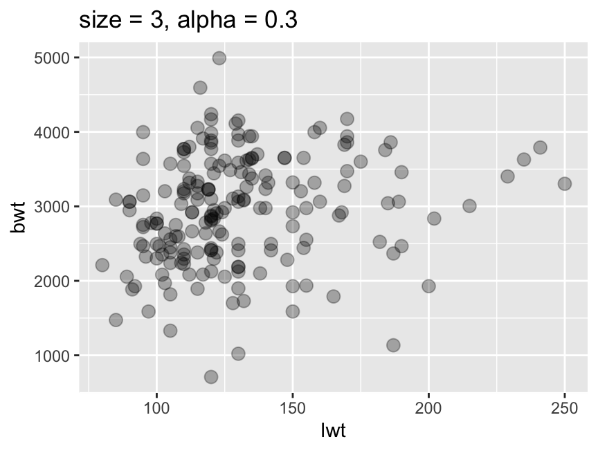

```r
ggplot(birthwt, aes(x = lwt, y = bwt)) +
  geom_point(size = 3) +
  labs(title = "size = 3, opacos")
ggplot(birthwt, aes(x = lwt, y = bwt)) +
  geom_point(size = 3, alpha = 0.3) +
  labs(title = "size = 3, alpha = 0.3")
```

Ojo: en `geom_text()` el `size` también existe, pero mide **la letra** (en milímetros), no un punto. Y el grosor de una **línea** o de un **borde** ya no se escribe `size` sino `linewidth`.

### `geom_jitter()` contra `geom_point()`

`geom_jitter()` es un `geom_point()` que **mueve cada punto un poco al azar** para que no se encimen. Sirve cuando un eje es **categórico** y todos los puntos de un grupo caen en la misma línea.

- `width`: cuánto se mueve a los lados.
- `height`: cuánto se mueve arriba y abajo.

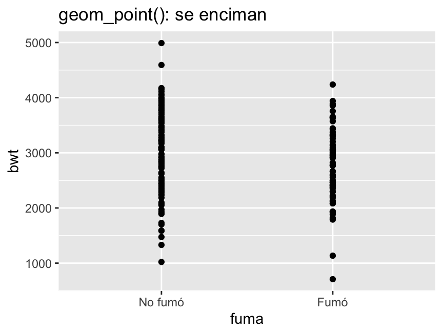

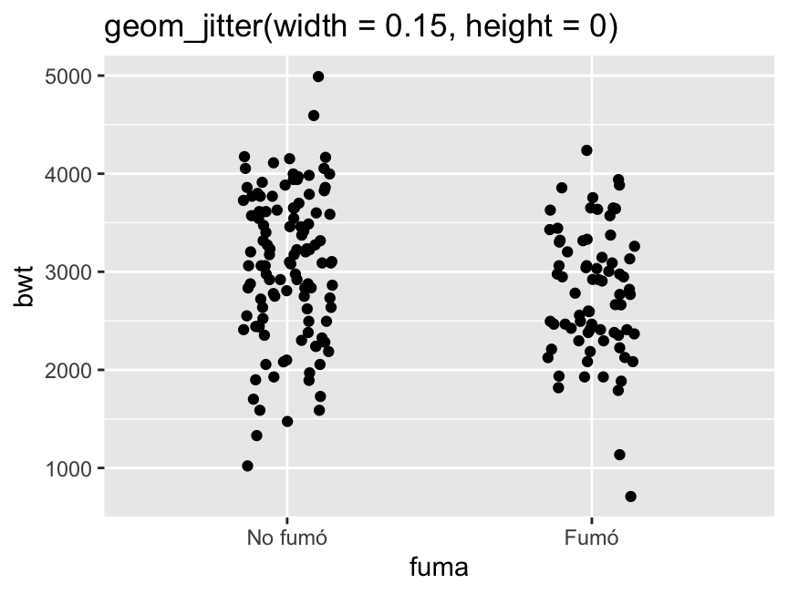

```r
ggplot(birthwt, aes(x = fuma, y = bwt)) +
  geom_point() +
  labs(title = "geom_point(): se enciman")
ggplot(birthwt, aes(x = fuma, y = bwt)) +
  geom_jitter(width = 0.15, height = 0) +
  labs(title = "geom_jitter(width = 0.15, height = 0)")
```

**Importante**

Pon siempre `height = 0` cuando el eje `y` es **numérico**. Si no, el ruido también mueve los puntos hacia arriba o abajo, y el peso que se ve en la gráfica **ya no es el peso real** del bebé. Moverlos a los lados no cambia nada, porque el eje `x` solo dice el grupo.

### `geom_boxplot()`: `outlier.shape`

`geom_boxplot()` dibuja los valores atípicos como puntos. Si encima se pone una capa de `geom_jitter()` con **todos** los datos, los atípicos salen **dos veces**: uno de la caja y otro del jitter. `outlier.shape = NA` le pide a la caja que no dibuje los suyos.

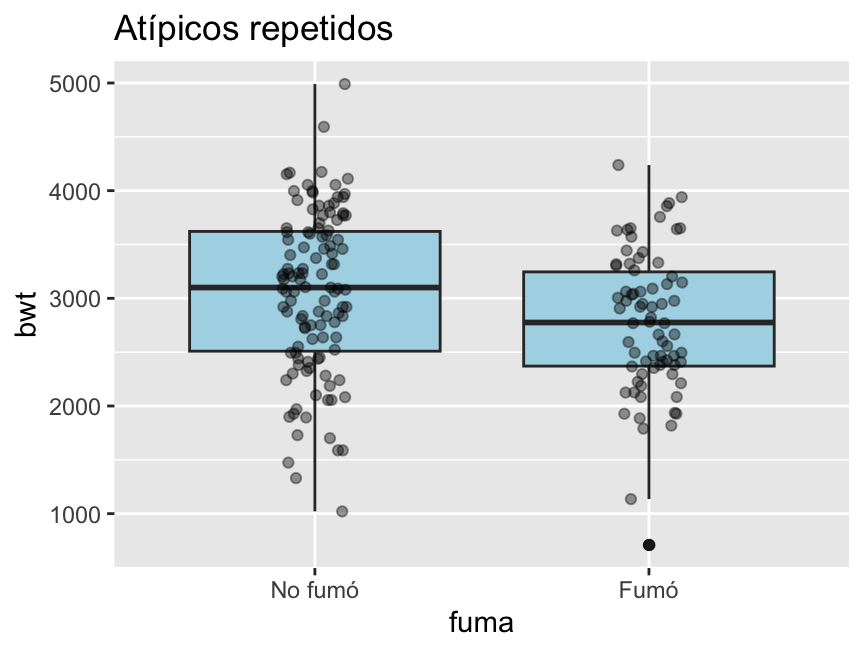

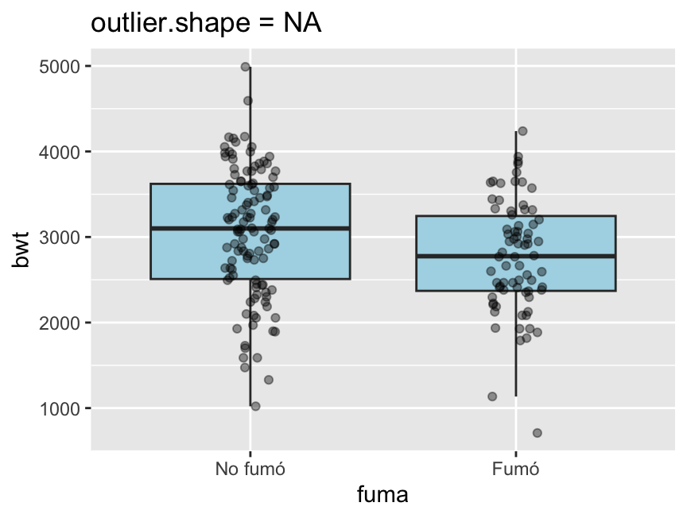

```r
ggplot(birthwt, aes(x = fuma, y = bwt)) +
  geom_boxplot(fill = "lightblue") +
  geom_jitter(width = 0.1, height = 0, alpha = 0.4) +
  labs(title = "Atípicos repetidos")
ggplot(birthwt, aes(x = fuma, y = bwt)) +
  geom_boxplot(fill = "lightblue", outlier.shape = NA) +
  geom_jitter(width = 0.1, height = 0, alpha = 0.4) +
  labs(title = "outlier.shape = NA")
```

Sin capa de puntos encima, **no** se usa `outlier.shape = NA`: se perderían los atípicos de la gráfica.

### `geom_text()`: `hjust` y `vjust`

Mueven el texto respecto a su lugar:

| Argumento | Mueve en | 0 | 0.5 (por omisión) | 1 |
| --- | --- | --- | --- | --- |
| `hjust` | horizontal | el texto **empieza** en el punto | centrado | el texto **termina** en el punto |
| `vjust` | vertical | el texto queda **arriba** del punto | centrado | el texto queda **abajo** del punto |

Los valores **menores que 0 o mayores que 1** lo alejan todavía más. Por eso en el notebook `hjust = -0.2` pone el número un poco **a la derecha** del final de cada barra acostada, y `vjust = -0.4` lo pone un poco **arriba** de una barra parada.

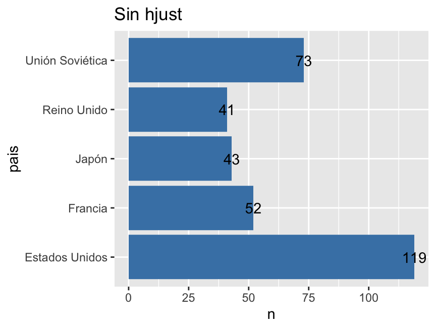

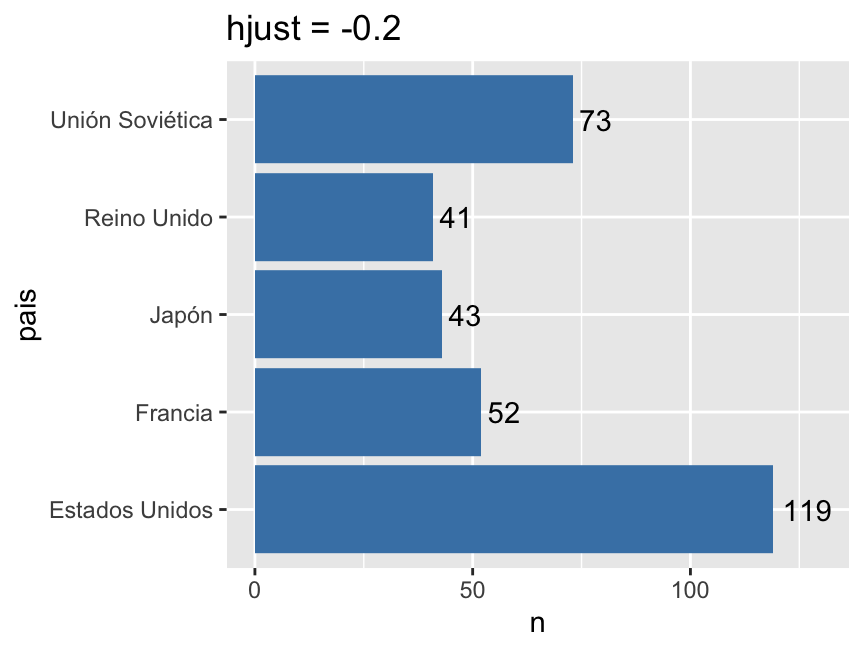

```r
ggplot(cinco, aes(x = n, y = pais)) +
  geom_col(fill = "steelblue") +
  geom_text(aes(label = n)) + # hjust = 0.5: centrado en la punta
  labs(title = "Sin hjust")
ggplot(cinco, aes(x = n, y = pais)) +
  geom_col(fill = "steelblue") +
  geom_text(aes(label = n), hjust = -0.2) +
  xlim(0, 130) + # deja espacio a la derecha para el número
  labs(title = "hjust = -0.2")
```

`hjust` también aparece dentro de `element_text()` (sección 7), con el mismo significado pero para los textos de los ejes.

## 4. El orden de las categorías: `reorder()` y `factor()`

ggplot2 ordena las categorías **alfabéticamente** si no se le dice otra cosa. Hay dos formas de cambiar el orden, y sirven para cosas distintas:

| Herramienta | Ordena según | Cuándo se usa | Ejemplo del notebook |
| --- | --- | --- | --- |
| `reorder(pais, n)` | **otra columna numérica** | cuando el orden debe seguir a los datos (de mayor a menor) | barras de centrales |
| `factor(..., levels = ...)` | **el orden que tú escribes** | cuando las categorías tienen un orden propio (antes → después; pequeño → grande) | grupos de endorfina |

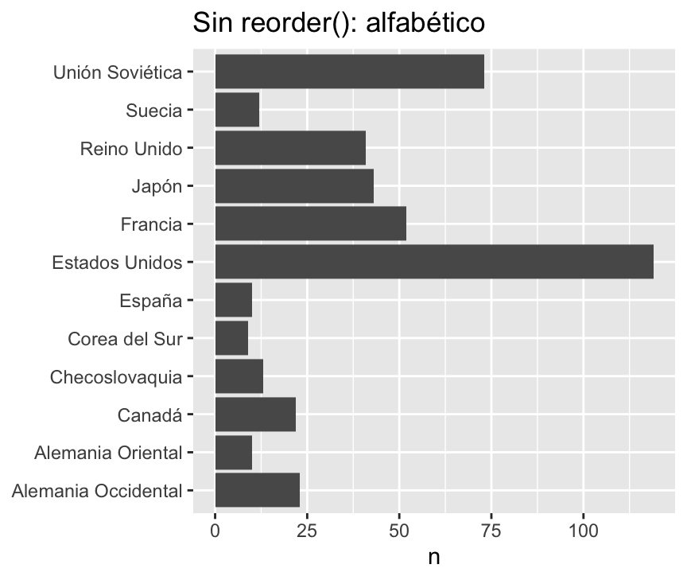

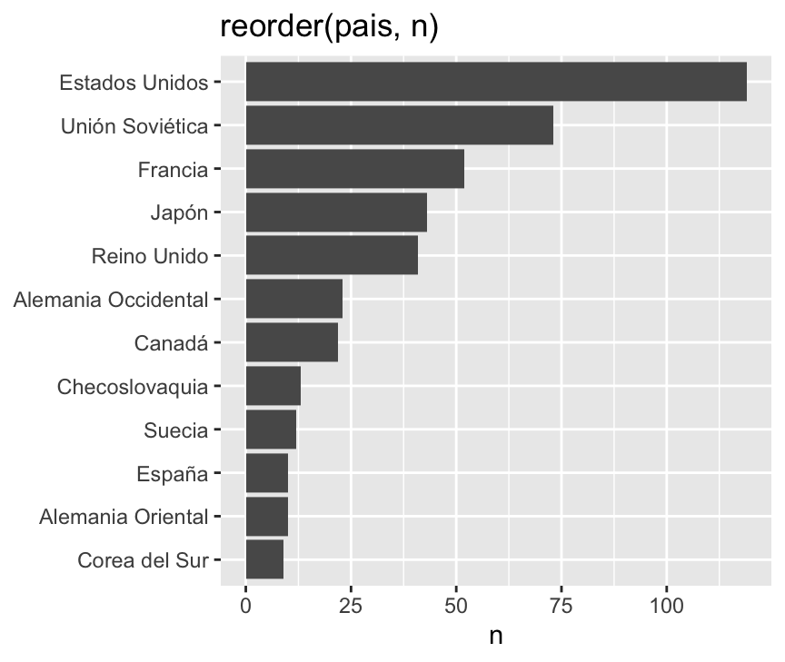

```r
ggplot(nucleares, aes(x = n, y = pais)) +
  geom_col() +
  labs(title = "Sin reorder(): alfabético", y = NULL)
ggplot(nucleares, aes(x = n, y = reorder(pais, n))) +
  geom_col() +
  labs(title = "reorder(pais, n)", y = NULL)
```

`reorder(pais, n)` pone **abajo** el valor más chico y **arriba** el más grande. Para invertirlo, `reorder(pais, -n)`: el signo menos ordena al revés.

## 5. Los ejes: `xlim()` contra `coord_cartesian()`

Las dos «acercan» un eje, pero hacen cosas muy distintas, y la diferencia importa en las barras:

|  | `xlim()`, `ylim()` | `coord_cartesian(xlim = , ylim = )` |
| --- | --- | --- |
| Qué hace | **borra** los datos que caen fuera del rango, y después dibuja | dibuja **todos** los datos y después **acerca la cámara** |
| Con barras | una barra que empieza en 0 queda fuera del rango y **desaparece**, con un aviso | las barras se ven, **cortadas** |
| Con un resumen (caja, media) | el resumen se calcula **sin** los datos borrados: cambia | el resumen no cambia |
| Para qué sirve | **alargar** un eje (dejar espacio para un texto) | **acercar** sin perder datos |

Sentido común: `xlim()` es recortar la foto con tijeras; `coord_cartesian()` es hacer zoom con la cámara.

```r
dos_paises <- nucleares[nucleares$pais %in% c("Japón", "Reino Unido"), ]

ggplot(dos_paises, aes(x = pais, y = n)) +
  geom_col() +
  ylim(40, 44) +
  labs(title = "ylim(40, 44): sin barras")
```

```
Warning: Removed 2 rows containing missing values or values outside the scale range
(`geom_col()`).
```

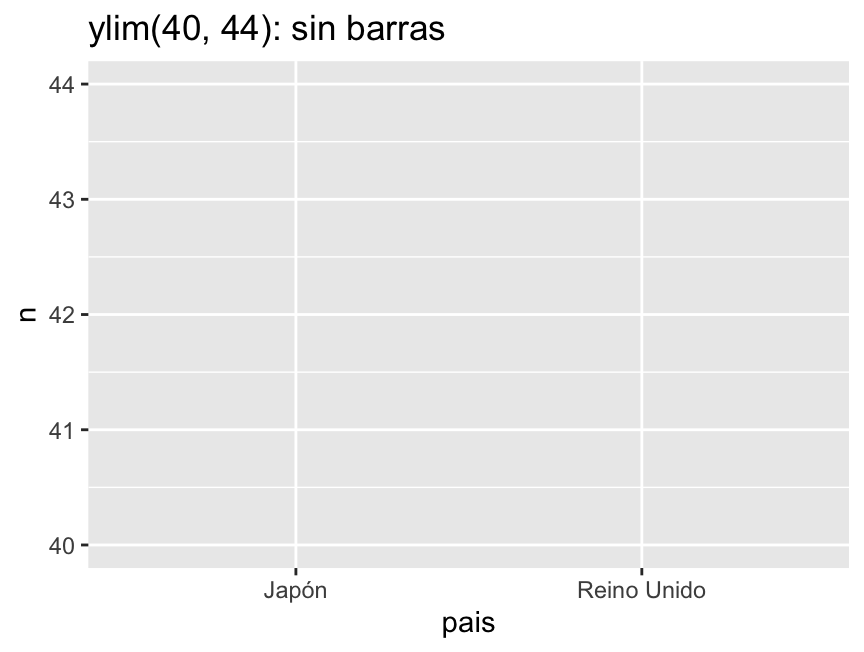

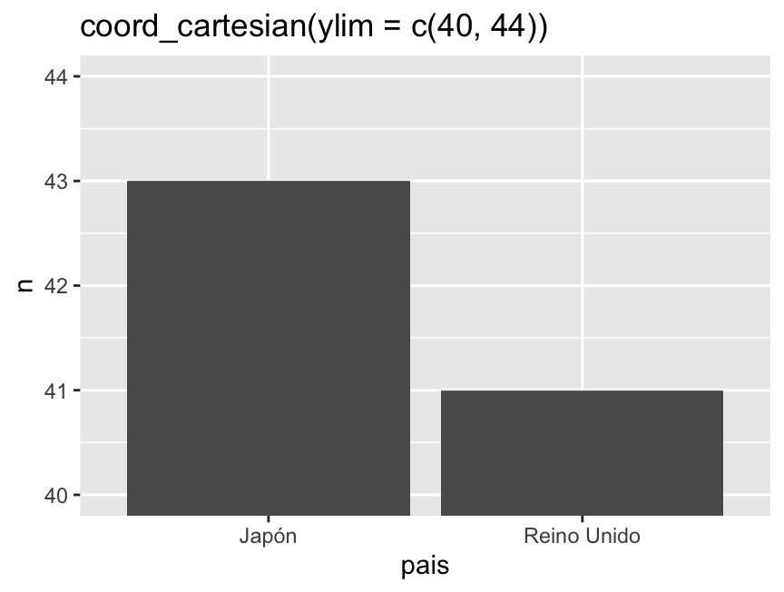

```r
ggplot(dos_paises, aes(x = pais, y = n)) +
  geom_col() +
  coord_cartesian(ylim = c(40, 44)) +
  labs(title = "coord_cartesian(ylim = c(40, 44))")
```

Mira el aviso que dio el primer bloque: `Removed 2 rows`. ggplot2 borró las dos barras porque empiezan en 0, fuera del rango de 40 a 44. Por eso en el notebook se usa `xlim()` solo para **alargar** el eje (`xlim(0, 130)`, para que quepa el 119 de Estados Unidos) y `coord_cartesian()` para **acercarlo**.